# 1. Setting Environment

```python
import pandas as pd
import re
import matplotlib
import datetime
import numpy as np
import scipy.special

from bokeh.layouts import gridplot
from bokeh.plotting import figure, show, output_file
```

```python
from os import chdir, getcwd
```

```python
wd=getcwd()
chdir('C:\\Users\\Jungwoo Lim\\Documents\\2018년 과제\\PSAT\\엘포인트공모전')
```

```python
import warnings
warnings.filterwarnings('ignore')
```

### Q. CLNT_ID?

- PC/모바일에 접속하는 순간 방문자로 인지, 쿠키에 랜덤으로 부여된 Client ID가 발급됨
- 디바이스, 브라우저 체제에 따라 다른 방문자로 인식
- 한 사람에게 여러 개 Client ID 존재 가능

### Q. SESS_ID?

- 세션은 방문자가 일정한 기간 내에 웹/앱 사이트에 방문하여 활동하는 영역을 의미
- 세션 시작 시 세션 ID가 발급된다.
- 세션이 변경, 만료되는 경우
  1. 사이트 간 이동(롯데닷컴, 롯데마트, 롯데슈퍼 다 다른 사이트로 취급)
  2. 세션 활동이 없을 경우 30분 후 세션 만료,
  3. 자정에 세션 만료

# 2. Loading Data & EDA

### 2.1 data

```python
data = pd.read_csv('제5회 Big Data Competition-분석용데이터-01.Pruduct.csv',engine='python',encoding='utf-8')
```

```python
data.reset_index(level=None,inplace=True)
```

```python
data.columns= ['CLNT_ID','SESS_ID','HITS_SEQ','PD_C','PD_ADD_NM','PD_BRA_NM','PD_BUY_AM','PD_BUY_CT']
```

```python
data.sort_values(by='CLNT_ID')
#이렇게 보니까
# 1) 한 ClientID에, 한 SessionID만 가지고 산 사람이 있고,
# 2) 한 ClientID이지만, 여러 SessionID가 있는 애들이 있다.
# >>즉 2)번은 고민을 좀 한 애들이라는 뜻일것이다.
```

|  | CLNT_ID | SESS_ID | HITS_SEQ | PD_C | PD_ADD_NM | PD_BRA_NM | PD_BUY_AM | PD_BUY_CT |
| --- | --- | --- | --- | --- | --- | --- | --- | --- |
| 4855606 | 8 | 7017688 | 74 | 206218 | 색상:BLACK\|사이즈:ONE SIZE / 1개 | 플라넷비 | 38,000 | 1 |
| 4830541 | 8 | 6964877 | 40 | 206218 | 색상:BLACK\|사이즈:ONE SIZE / 1개 | 플라넷비 | 38,000 | 1 |
| 5015932 | 14 | 1156991 | 284 | 369141 | 색상:LL2G16216RGB\|사이즈:FREE / 1개 | 로이드 | 39,900 | 1 |
| 4386392 | 14 | 1156991 | 284 | 645262 | 색상:LL1G14817AIN\|사이즈:FREE / 1개 | 로이드(주얼리) | 29,900 | 1 |
| 2346683 | 25 | 8113243 | 9 | 715121 | (not set) | [이롬] | 92,000 | 1 |
| 2346684 | 25 | 9506206 | 11 | 715121 | (not set) | [이롬] | 92,000 | 1 |
| 728476 | 25 | 6059256 | 8 | 715072 | (not set) | [이롬] | 47,000 | 1 |
| 56434 | 25 | 5317297 | 8 | 598634 | 피테로마 때박살:피테로마 때박살 120종 | [유씨지] | 39,800 | 1 |
| 2591162 | 32 | 1136737 | 72 | 48881 | 색상:선택01_DNV\|사이즈:105(XL) / 1개 | 엠폴햄 | 13,500 | 1 |
| 2650245 | 32 | 1136737 | 72 | 48881 | 색상:선택01_SBL\|사이즈:105(XL) / 1개 | 엠폴햄 | 13,500 | 1 |
| 4430100 | 32 | 1136737 | 72 | 38697 | 스타일:10.RHHMSJ59T\|사이즈:106 / 1개 | 레노마캐주얼 | 30,000 | 1 |
| 1670221 | 32 | 759569 | 37 | 31974 | 선택:PUE30513S / 1개 | 푸마 | 9,900 | 1 |
| 1592491 | 32 | 759569 | 37 | 31982 | 선택:PUE30520S / 1개 | 푸마 | 9,900 | 1 |
| 1111261 | 33 | 8694850 | 23 | 613253 | (not set) | [다우니] | 7,900 | 1 |
| 661184 | 33 | 10548225 | 13 | 605825 | (not set) | [슈에무라] | 49,000 | 1 |
| 2437131 | 33 | 10300429 | 28 | 806941 | (not set) | [에뛰드하우스] | 12,500 | 1 |
| 3869892 | 33 | 8694850 | 23 | 607160 | (not set) | [바티스트] | 22,220 | 1 |
| 3859684 | 33 | 9521159 | 14 | 607160 | (not set) | [바티스트] | 22,220 | 1 |
| 3802561 | 51 | 9007214 | 36 | 777632 | (not set) | [이딸라] | 22,000 | 1 |
| 3841405 | 51 | 9007214 | 31 | 777632 | (not set) | [이딸라] | 22,000 | 1 |
| 531996 | 56 | 2108568 | 57 | 425529 | 선택:데일리 디펜스 / 1개 | 비욘드 | 4,500 | 1 |
| 531997 | 56 | 2108568 | 57 | 425529 | 선택:딥모이 / 1개 | 비욘드 | 4,500 | 1 |
| 2800931 | 56 | 5747479 | 28 | 824386 | 1개 | 코리아보드게임즈 | 14,800 | 1 |
| 4111058 | 58 | 4328876 | 209 | 420859 | 색상:19_블랙\|사이즈:90S / 1개 | 뉴발란스(의류) | 26,000 | 1 |
| 4395633 | 58 | 4328876 | 209 | 417290 | 색상:선택02_그레이\|사이즈:90 / 1개 | 엠엘비 | 29,500 | 1 |
| 3620784 | 58 | 4328876 | 209 | 243342 | 색상:DNV\|사이즈:160 / 1개 | 폴햄 | 19,900 | 1 |
| 3769660 | 58 | 4328876 | 209 | 146452 | 색상:LIN\|사이즈:160 / 1개 | 폴햄 | 20,900 | 1 |
| 2675769 | 58 | 4328876 | 209 | 146435 | 색상:WT\|사이즈:160 / 1개 | 폴햄 | 13,900 | 1 |
| 3749855 | 58 | 4328876 | 209 | 146452 | 색상:MIN\|사이즈:160 / 1개 | 폴햄 | 20,900 | 1 |
| 1270112 | 59 | 400685 | 59 | 780899 | 1개 | 코렐코디네이츠 | 8,500 | 1 |
| ... | ... | ... | ... | ... | ... | ... | ... | ... |
| 3562972 | 6592536 | 61570 | 56 | 502688 | 색상:핑크\|사이즈:85 / 1개 | 클라이드 | 19,000 | 1 |
| 4461507 | 6592536 | 1347403 | 227 | 572070 | 모델:옵션14\|셔츠사이즈:105 / 1개 | 레노마(셔츠) | 30,000 | 1 |
| 3213480 | 6592537 | 294554 | 37 | 584475 | 색상:500(LIGHT_BEIGE)\|사이즈:66 / 1개 | 아이잗바바 | 384,000 | 1 |
| 3356763 | 6592537 | 386248 | 52 | 69351 | 색상:네이비\|치수:S(55) / 1개 | 질스튜어트(영패션) | 323,100 | 1 |
| 2732860 | 6592544 | 8270794 | 14 | 284460 | 타입:세트 | [설화수] | 120,000 | 3 |
| 1002708 | 6592544 | 8270794 | 14 | 706193 | 타입:세트 | [설화수] | 52,000 | 1 |
| 1808016 | 6592551 | 1352463 | 170 | 829686 | 미미로린스 드레스퍼퓸:05. 프레쉬 라임\|미미로린스 드레스 퍼퓸:05. 프레쉬 라임... | 미미로린스 | 9,900 | 1 |
| 2168236 | 6592551 | 1107655 | 71 | 751413 | 선택:브라운(K299ON) / 1개 | 키스미 | 11,200 | 1 |
| 1380114 | 6592551 | 1352463 | 170 | 815842 | 선택:07. 바디크림 : 프레쉬라임+프레쉬라임 / 1개 | 미미로린스 | 8,900 | 1 |
| 353935 | 6592553 | 2537044 | 11 | 709602 | 1개 | 이니스프리 | 3,000 | 1 |
| 272709 | 6592553 | 2537044 | 11 | 709611 | 1개 | 이니스프리 | 2,400 | 1 |
| 1082909 | 6592553 | 2537044 | 11 | 709608 | 1개 | 이니스프리 | 7,200 | 1 |
| 51696 | 6592553 | 2537044 | 11 | 636492 | 1개 | 이니스프리 | 550 | 1 |
| 48454 | 6592553 | 2537044 | 11 | 636487 | 1개 | 이니스프리 | 550 | 1 |
| 4634343 | 6592553 | 3241408 | 31 | 810304 | 1개 | 헬렌스타인 | 33,900 | 1 |
| 177649 | 6592553 | 3241408 | 31 | 5977 | 1개 | 본타몰 | 1,600 | 1 |
| 4094847 | 6592553 | 3241408 | 31 | 113030 | 상품코드:05_892764_010\|사이즈:FREE / 1개 | 나이키골프 | 25,000 | 1 |
| 3717542 | 6592553 | 3241408 | 31 | 547925 | 색상:스카이 블루\|Size:S / 1개 | 에잇세컨즈 | 19,900 | 1 |
| 3113148 | 6592553 | 2537044 | 11 | 639558 | 1개 | 이니스프리 | 15,000 | 1 |
| 2120591 | 6592553 | 2537044 | 11 | 511415 | 1개 | 이니스프리 | 10,800 | 1 |
| 3708483 | 6592553 | 3241408 | 31 | 225586 | 색상:네이비(275)\|사이즈:FREE(000) / 1개 | 에이치커넥트 | 19,900 | 1 |
| 4005440 | 6592553 | 3241408 | 31 | 420913 | 색상:49_카키\|사이즈:105XL / 1개 | 뉴발란스(의류) | 24,100 | 1 |
| 5293 | 6592553 | 2537044 | 11 | 636488 | 1개 | 이니스프리 | 550 | 1 |
| 3075526 | 6592553 | 3241408 | 31 | 120039 | 색상:화이트(022)\|사이즈:FREE(000) / 1개 | 에이치커넥트 | 15,000 | 1 |
| 196541 | 6592553 | 2537044 | 11 | 709612 | 1개 | 이니스프리 | 2,400 | 1 |
| 199109 | 6592553 | 2537044 | 11 | 827417 | 1개 | 이니스프리 | 2,100 | 1 |
| 120456 | 6592554 | 7240794 | 9 | 255120 | 색상:브라운(Brown)/사이즈:235mm | [사뿐(Sappun)] | 40,900 | 1 |
| 4822824 | 6592554 | 7240794 | 9 | 455338 | 컬러:핫 레드 | [나스] | 37,000 | 2 |
| 287918 | 6592554 | 7240794 | 9 | 742670 | 색상:토프 | [바비브라운] | 42,000 | 1 |
| 416807 | 6592554 | 7240794 | 9 | 344451 | 색상:641 오렌지 | [디올] | 43,000 | 1 |

5024906 rows × 8 columns

### 데이터 크기

```python
data.info() #데이터 형변환을 해야겠군!
```

```
<class 'pandas.core.frame.DataFrame'>
RangeIndex: 5024906 entries, 0 to 5024905
Data columns (total 8 columns):
CLNT_ID      int64
SESS_ID      int64
HITS_SEQ     int64
PD_C         int64
PD_ADD_NM    object
PD_BRA_NM    object
PD_BUY_AM    object
PD_BUY_CT    object
dtypes: int64(4), object(4)
memory usage: 306.7+ MB
```

### 형변환 하기! (CLNT_ID, SESS_ID, PD_C > object, PD_BUY_CT > integer로 바꿀 것)

```python
data.CLNT_ID = data.CLNT_ID.astype(str)
```

```python
data.SESS_ID = data.SESS_ID.astype(str)
```

```python
data.PD_C = data.PD_C.astype(str)
```

```python
data.PD_BUY_CT = data.PD_BUY_CT.apply(lambda x:x.replace(',',''))
```

```python
data.PD_BUY_CT = data.PD_BUY_CT.astype('int64')
```

```python
data.PD_BUY_AM = data.PD_BUY_AM.apply(lambda x:x.replace(',',''))
```

```python
data.PD_BUY_AM = data.PD_BUY_AM.astype('int64')
```

```python
data.info() #확인해보았다. 잘 바꼈군!
```

```
<class 'pandas.core.frame.DataFrame'>
RangeIndex: 5024906 entries, 0 to 5024905
Data columns (total 8 columns):
CLNT_ID      object
SESS_ID      object
HITS_SEQ     int64
PD_C         object
PD_ADD_NM    object
PD_BRA_NM    object
PD_BUY_AM    int64
PD_BUY_CT    int64
dtypes: int64(3), object(5)
memory usage: 306.7+ MB
```

### 데이터 기본 탐색

```python
import matplotlib
```

```python
data = data.loc[data.HITS_SEQ> 1]
```

```python
import matplotlib as mpl
import matplotlib.pyplot as plt
import matplotlib.font_manager as fm
from matplotlib import rcParams
```

```python
rcParams['figure.figsize'] = 12,4
```

```python
print ('버전: ', mpl.__version__)
print ('설치 위치: ', mpl.__file__)
print ('설정 위치: ', mpl.get_configdir())
print ('캐시 위치: ', mpl.get_cachedir())
print ('설정파일 위치: ', mpl.matplotlib_fname())
# figure size in inches
rcParams['figure.figsize'] = 11.7,8.27
font_list = fm.findSystemFonts(fontpaths=None, fontext='ttf')

# ttf 폰트 전체갯수
print(len(font_list))
font_list[:10]
[(f.name, f.fname) for f in fm.fontManager.ttflist if 'Nanum' in f.name]

# size, family
print('# 설정 되어있는 폰트 사이즈')
print (plt.rcParams['font.size'] )
print('# 설정 되어있는 폰트 글꼴')
print (plt.rcParams['font.family'] )


plt.rcParams["font.family"] = 'NanumBarunGothic'
plt.rcParams["font.size"] = 10
```

```
버전:  2.2.2
설치 위치:  C:\Users\Jungwoo Lim\Anaconda3\lib\site-packages\matplotlib\__init__.py
설정 위치:  C:\Users\Jungwoo Lim\.matplotlib
캐시 위치:  C:\Users\Jungwoo Lim\.matplotlib
설정파일 위치:  C:\Users\Jungwoo Lim\Anaconda3\lib\site-packages\matplotlib\mpl-data\matplotlibrc
843
# 설정 되어있는 폰트 사이즈
10.0
# 설정 되어있는 폰트 글꼴
['sans-serif']
```

```python
import seaborn as sns, numpy as np
sns.set();
```

[figure not shown]

```python
sns.set_color_codes()
f, axes = plt.subplots(1, 1, figsize=(7, 7), sharex=True)
sns.despine(left=True)
```

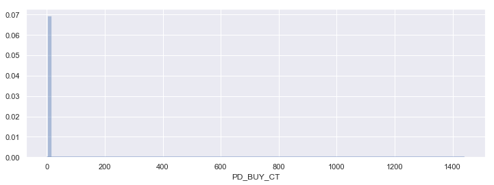

```python
sns.distplot(data.PD_BUY_CT,bins=100,kde_kws={"shade": False})
```

```python
data.quantile(0.99)
```

```
HITS_SEQ        416.0
PD_BUY_AM    418070.0
PD_BUY_CT         4.0
Name: 0.99, dtype: float64
```

```python
pd.DataFrame(data.PD_BRA_NM.value_counts())
```

|  | PD_BRA_NM |
| --- | --- |
| 지오다노 | 73483 |
| 나이키 | 48555 |
| 정관장 | 33489 |
| 에이치커넥트 | 31971 |
| 탑텐 | 31507 |
| 크록스 | 30592 |
| 입생로랑 | 26030 |
| 아디다스(의류) | 25643 |
| [지오다노] | 22174 |
| 첨이첨이 | 21880 |
| 맥 | 20715 |
| 블루독 | 20274 |
| 코데즈컴바인 이너웨어 | 20129 |
| 나스 | 19749 |
| 헤지스남성 | 19346 |
| 엘르이너웨어 | 18171 |
| 조르지오 아르마니 | 17586 |
| 랩 | 17300 |
| 디스커버리 | 16905 |
| 설화수 | 16299 |
| 레노마키즈 | 16192 |
| 난닝구 | 15781 |
| 바보사랑 | 15660 |
| 제이제이 지고트 | 15204 |
| 에고이스트 | 15024 |
| 엠엘비키즈 | 14886 |
| 래핑차일드 | 14744 |
| 아디다스(슈즈) | 14169 |
| 노스페이스 | 13756 |
| 쉬즈미스 | 13417 |
| ... | ... |
| [숀화이트 서플라이] | 1 |
| 카이코 | 1 |
| [퓨어365] | 1 |
| 코이바나 | 1 |
| 위젠 | 1 |
| 하이원 | 1 |
| 알텍랜싱 | 1 |
| [탤론] | 1 |
| 마드미젠 | 1 |
| 투마씨앤디 | 1 |
| 아쿠아주라 | 1 |
| 프로텍트엠 | 1 |
| [카사업] | 1 |
| 펫분 | 1 |
| 289934 | 1 |
| 인버디 | 1 |
| [겐조(잡화)] | 1 |
| [필모리스] | 1 |
| [톰슨] | 1 |
| 2053240 | 1 |
| [프리미아타] | 1 |
| 바로쿡 | 1 |
| 휴엘라 | 1 |
| [스타루스] | 1 |
| Arte inter | 1 |
| 크리에이티브커버스 | 1 |
| [밀라노(가전)] | 1 |
| 쿠스쿠스파이 | 1 |
| [트럼프홈] | 1 |
| [스텐하우스] | 1 |

22716 rows × 1 columns

```python
data['PD_BRA_NM2'] = data.PD_BRA_NM.apply(lambda x:re.sub(r'[\]\[]','',x))
data['PD_BRA_NM2'] = data.PD_BRA_NM2.apply(lambda x:re.sub(r'\([a-zA-Zㄱ-히\)]+','',x))
data['PD_BRA_NM2'] = data.PD_BRA_NM2.apply(lambda x:x.strip())
data['PD_BRA_NM2'] = data.PD_BRA_NM2.apply(lambda x:re.sub(r'[ .]','',x))
```

```python
data['PD_BRA_NM2'] = data.PD_BRA_NM.apply(lambda x:re.sub(r'[1+1]{3}','VSER',x))
data['PD_BRA_NM2'] = data.PD_BRA_NM2.apply(lambda x:re.sub(r'[100%국내생산]{8}','대한산업',x))
data['PD_BRA_NM2'] = data.PD_BRA_NM2.apply(lambda x:re.sub(r'[기존가:39|900원]{11}','코너샵',x))
data['PD_BRA_NM2'] = data.PD_BRA_NM2.apply(lambda x:re.sub(r'[기존가:88|900원]{11}','Harrod',x))
data['PD_BRA_NM2'] = data.PD_BRA_NM2.apply(lambda x:re.sub(r'[기타]{2}','r[기타브랜드]',x))
data['PD_BRA_NM2'] = data.PD_BRA_NM2.apply(lambda x:re.sub(r'[바비|]{3}','바비',x))
data['PD_BRA_NM2'] = data.PD_BRA_NM2.apply(lambda x:re.sub(r'[선데이에프터눈즈]{8}','선데이애프터눈즈',x))
data['PD_BRA_NM2'] = data.PD_BRA_NM2.apply(lambda x:re.sub(r'[아디다스오리지날]{8}','아디다스오리지널',x))
data['PD_BRA_NM2'] = data.PD_BRA_NM2.apply(lambda x:re.sub(r'[엘지전자]{4}','LG전자',x))
data['PD_BRA_NM2'] = data.PD_BRA_NM2.apply(lambda x:re.sub(r'[젠정장)]{4}','젠정장',x))
data['PD_BRA_NM2'] = data.PD_BRA_NM2.apply(lambda x:re.sub(r'[조말론런던MaloneLondon)]{18}','조말론런던',x))
data['PD_BRA_NM2'] = data.PD_BRA_NM2.apply(lambda x:re.sub(r'[종근당건강1]{6}','종근당건강',x))
data['PD_BRA_NM2'] = data.PD_BRA_NM2.apply(lambda x:re.sub(r'[지프|잡화브이아이피)]{11}','지프|잡화브이아이피',x))

data['PD_BRA_NM2'] = data.PD_BRA_NM2.apply(lambda x:re.sub(r'[2인세트]{4}','에코슬립 닥터카이로',x)) #총 21개 확인
data['PD_BRA_NM2'] = data.PD_BRA_NM2.apply(lambda x:re.sub(r'[3+1]{3}','헬스타임',x))
data['PD_BRA_NM2'] = data.PD_BRA_NM2.apply(lambda x:re.sub(r'[31%할인]{5}','NUTZ',x))
data['PD_BRA_NM2'] = data.PD_BRA_NM2.apply(lambda x:re.sub(r'[360도 회전식 옷걸이]{12}','논슬립 매직행거',x))
data['PD_BRA_NM2'] = data.PD_BRA_NM2.apply(lambda x:re.sub(r'[3분할/4.5M]{8}','윈도우스토리',x))
data['PD_BRA_NM2'] = data.PD_BRA_NM2.apply(lambda x:re.sub(r'[2분할/3.5M]{8}','에코슬립 닥터카이로',x))
data['PD_BRA_NM2'] = data.PD_BRA_NM2.apply(lambda x:re.sub(r'[4+1]{3}','지음',x))
data['PD_BRA_NM2'] = data.PD_BRA_NM2.apply(lambda x:re.sub(r'[45팩]{3}','글램디',x))
data['PD_BRA_NM2'] = data.PD_BRA_NM2.apply(lambda x:re.sub(r'[4개월]{3}','프롬바이오',x))
data['PD_BRA_NM2'] = data.PD_BRA_NM2.apply(lambda x:re.sub(r'[50동 한정]{6}','지오프리',x))
data['PD_BRA_NM2'] = data.PD_BRA_NM2.apply(lambda x:re.sub(r'[56번가]{4}','카파맥스',x))
data['PD_BRA_NM2'] = data.PD_BRA_NM2.apply(lambda x:re.sub(r'[5통]{2}','종근당',x))
data['PD_BRA_NM2'] = data.PD_BRA_NM2.apply(lambda x:re.sub(r'[4인세트]{4}','에코슬립 닥터카이로',x))
data['PD_BRA_NM2'] = data.PD_BRA_NM2.apply(lambda x:re.sub(r'[6colors]{7}','베스트로 쿨스킨 암숄더 스트라이프 이너웨어',x))
data['PD_BRA_NM2'] = data.PD_BRA_NM2.apply(lambda x:re.sub(r'[857-05]{6}','블루마토',x))
data['PD_BRA_NM2'] = data.PD_BRA_NM2.apply(lambda x:re.sub(r'[8개월]{3}','프롬바이오',x))
data['PD_BRA_NM2'] = data.PD_BRA_NM2.apply(lambda x:re.sub(r'[9월5일부터 순차출고]{11}','그린지오',x))

data['PD_BRA_NM2'] = data.PD_BRA_NM2.apply(lambda x:re.sub(r'[AH2613]{6}','아디다스(키즈)',x))
data['PD_BRA_NM2'] = data.PD_BRA_NM2.apply(lambda x:re.sub(r'[AH2614]{6}','아디다스(키즈)',x))
data['PD_BRA_NM2'] = data.PD_BRA_NM2.apply(lambda x:re.sub(r'[AH2627]{6}','아디다스(키즈)',x))
data['PD_BRA_NM2'] = data.PD_BRA_NM2.apply(lambda x:re.sub(r'[AH2628]{6}','아디다스(키즈)',x))

data['PD_BRA_NM2'] = data.PD_BRA_NM2.apply(lambda x:re.sub(r'[BC0018]{6}','아디다스',x))
data['PD_BRA_NM2'] = data.PD_BRA_NM2.apply(lambda x:re.sub(r'[B75613]{6}','아디다스',x))
data['PD_BRA_NM2'] = data.PD_BRA_NM2.apply(lambda x:re.sub(r'[BI4526]{6}','아디다스',x))
data['PD_BRA_NM2'] = data.PD_BRA_NM2.apply(lambda x:re.sub(r'[BUCAKROO]{8}','BUCKAROO',x))
data['PD_BRA_NM2'] = data.PD_BRA_NM2.apply(lambda x:re.sub(r'[CE5578]{6}','아디다스',x))
data['PD_BRA_NM2'] = data.PD_BRA_NM2.apply(lambda x:re.sub(r'[CE5580]{6}','아디다스',x))
data['PD_BRA_NM2'] = data.PD_BRA_NM2.apply(lambda x:re.sub(r'[CE9986]{6}','아디다스(키즈)',x))
data['PD_BRA_NM2'] = data.PD_BRA_NM2.apply(lambda x:re.sub(r'[CF7138]{6}','아디다스(키즈)',x))
data['PD_BRA_NM2'] = data.PD_BRA_NM2.apply(lambda x:re.sub(r'[CF7141]{6}','아디다스(키즈)',x))
data['PD_BRA_NM2'] = data.PD_BRA_NM2.apply(lambda x:re.sub(r'[CF7326]{6}','아디다스(키즈)',x))
data['PD_BRA_NM2'] = data.PD_BRA_NM2.apply(lambda x:re.sub(r'[CF8571]{6}','아디다스(키즈)',x))
data['PD_BRA_NM2'] = data.PD_BRA_NM2.apply(lambda x:re.sub(r'[CG3777]{6}','아디다스(키즈)',x))
data['PD_BRA_NM2'] = data.PD_BRA_NM2.apply(lambda x:re.sub(r'[CG5766]{6}','아디다스',x))
data['PD_BRA_NM2'] = data.PD_BRA_NM2.apply(lambda x:re.sub(r'[CG5800]{6}','아디다스',x))
data['PD_BRA_NM2'] = data.PD_BRA_NM2.apply(lambda x:re.sub(r'[CJ2144]{6}','아디다스',x))
data['PD_BRA_NM2'] = data.PD_BRA_NM2.apply(lambda x:re.sub(r'[CP9040]{6}','아디다스(키즈)',x))
data['PD_BRA_NM2'] = data.PD_BRA_NM2.apply(lambda x:re.sub(r'[CQ2537]{6}','아디다스',x))
data['PD_BRA_NM2'] = data.PD_BRA_NM2.apply(lambda x:re.sub(r'[D96066]{6}','아디다스(키즈)',x))
data['PD_BRA_NM2'] = data.PD_BRA_NM2.apply(lambda x:re.sub(r'[CP9040]{6}','아디다스(키즈)',x))
data['PD_BRA_NM2'] = data.PD_BRA_NM2.apply(lambda x:re.sub(r'[DB1346]{6}','아디다스',x))
data['PD_BRA_NM2'] = data.PD_BRA_NM2.apply(lambda x:re.sub(r'[DB1540]{6}','아디다스',x))
data['PD_BRA_NM2'] = data.PD_BRA_NM2.apply(lambda x:re.sub(r'[DJ1398]{6}','아디다스(키즈)',x))
data['PD_BRA_NM2'] = data.PD_BRA_NM2.apply(lambda x:re.sub(r'[CP9040]{6}','아디다스(키즈)',x))
data['PD_BRA_NM2'] = data.PD_BRA_NM2.apply(lambda x:re.sub(r'[CP9040]{6}','아디다스(키즈)',x))
data['PD_BRA_NM2'] = data.PD_BRA_NM2.apply(lambda x:re.sub(r'[CY4763]{6}','아디다스',x))

data['PD_BRA_NM2'] = data.PD_BRA_NM2.apply(lambda x:re.sub(r'[D271971]{7}','세종기업',x))
data['PD_BRA_NM2'] = data.PD_BRA_NM2.apply(lambda x:re.sub(r'[D559386]{7}','토이트론',x))
data['PD_BRA_NM2'] = data.PD_BRA_NM2.apply(lambda x:re.sub(r'[D961695]{7}','토이트론',x))
data['PD_BRA_NM2'] = data.PD_BRA_NM2.apply(lambda x:re.sub(r'[D559386]{7}','토이트론',x))
data['PD_BRA_NM2'] = data.PD_BRA_NM2.apply(lambda x:re.sub(r'[EWG인증]{5}','위드마이치약',x))
data['PD_BRA_NM2'] = data.PD_BRA_NM2.apply(lambda x:re.sub(r'[FPDFI2U24Z1]{11}','PONY',x))
data['PD_BRA_NM2'] = data.PD_BRA_NM2.apply(lambda x:re.sub(r'[FSSNH1U37B7]{11}','스프리스(신발)',x))
data['PD_BRA_NM2'] = data.PD_BRA_NM2.apply(lambda x:re.sub(r'[FW균일가한정]{7}','본',x))
data['PD_BRA_NM2'] = data.PD_BRA_NM2.apply(lambda x:re.sub(r'[FW한정상품]{6}','본',x))
data['PD_BRA_NM2'] = data.PD_BRA_NM2.apply(lambda x:re.sub(r'[GIFT SET]{8}','오리진',x))
data['PD_BRA_NM2'] = data.PD_BRA_NM2.apply(lambda x:re.sub(r'[HAM-002]{7}','하미',x))
data['PD_BRA_NM2'] = data.PD_BRA_NM2.apply(lambda x:re.sub(r'[JHBRT312]{8}','제임스딘',x))
data['PD_BRA_NM2'] = data.PD_BRA_NM2.apply(lambda x:re.sub(r'[JHGRT311]{8}','제임스딘',x))
data['PD_BRA_NM2'] = data.PD_BRA_NM2.apply(lambda x:re.sub(r'[LEVI\'S]{6}','리바이스',x))
data['PD_BRA_NM2'] = data.PD_BRA_NM2.apply(lambda x:re.sub(r'[LEVI\'s]{6}','리바이스',x))
data['PD_BRA_NM2'] = data.PD_BRA_NM2.apply(lambda x:re.sub(r'[LEVIS]{5}','리바이스',x))


data['PD_BRA_NM2'] = data.PD_BRA_NM2.apply(lambda x:re.sub(r'[M9165C]{6}','스프리스(신발)',x))
data['PD_BRA_NM2'] = data.PD_BRA_NM2.apply(lambda x:re.sub(r'[MDNA SKIN]{9}','MDNASKIN',x))
data['PD_BRA_NM2'] = data.PD_BRA_NM2.apply(lambda x:re.sub(r'[MD추천]{4}','Catronics',x))
data['PD_BRA_NM2'] = data.PD_BRA_NM2.apply(lambda x:re.sub(r'[MT 310]{6}','맥스토치',x))
data['PD_BRA_NM2'] = data.PD_BRA_NM2.apply(lambda x:re.sub(r'[NO.564]{6}','HP',x))
data['PD_BRA_NM2'] = data.PD_BRA_NM2.apply(lambda x:re.sub(r'[NO.61]{5}','HP',x))
data['PD_BRA_NM2'] = data.PD_BRA_NM2.apply(lambda x:re.sub(r'[NO.63XL]{7}','HP',x))
data['PD_BRA_NM2'] = data.PD_BRA_NM2.apply(lambda x:re.sub(r'[NO.703]{6}','HP',x))
data['PD_BRA_NM2'] = data.PD_BRA_NM2.apply(lambda x:re.sub(r'[NO.955XL]{8}','HP',x))
data['PD_BRA_NM2'] = data.PD_BRA_NM2.apply(lambda x:re.sub(r'[No.25206]{8}','블루마토',x))
data['PD_BRA_NM2'] = data.PD_BRA_NM2.apply(lambda x:re.sub(r'[No.60]{5}','HP',x))
data['PD_BRA_NM2'] = data.PD_BRA_NM2.apply(lambda x:re.sub(r'[O3579]{5}','한스킨',x))
data['PD_BRA_NM2'] = data.PD_BRA_NM2.apply(lambda x:re.sub(r'[OC001]{5}','오감찰바',x))
data['PD_BRA_NM2'] = data.PD_BRA_NM2.apply(lambda x:re.sub(r'[PGATOUR]{7}','PGA TOUR',x))
data['PD_BRA_NM2'] = data.PD_BRA_NM2.apply(lambda x:re.sub(r'[PGATOUR GOLF]{12}','PGA TOUR',x))
data['PD_BRA_NM2'] = data.PD_BRA_NM2.apply(lambda x:re.sub(r'[PR_0016]{7}','H&M',x))
data['PD_BRA_NM2'] = data.PD_BRA_NM2.apply(lambda x:re.sub(r'[QCX228]{6}','블루마토',x))
data['PD_BRA_NM2'] = data.PD_BRA_NM2.apply(lambda x:re.sub(r'[RLFDPT97O]{9}','리안뉴욕',x))
data['PD_BRA_NM2'] = data.PD_BRA_NM2.apply(lambda x:re.sub(r'[SKT 기기변경]{8}','LG전자',x))
data['PD_BRA_NM2'] = data.PD_BRA_NM2.apply(lambda x:re.sub(r'[W9402]{5}','블루마토',x))
data['PD_BRA_NM2'] = data.PD_BRA_NM2.apply(lambda x:re.sub(r'[WR110]{5}','씨엘스토리',x))
data['PD_BRA_NM2'] = data.PD_BRA_NM2.apply(lambda x:re.sub(r'[cj one]{6}','씨제이',x))
data['PD_BRA_NM2'] = data.PD_BRA_NM2.apply(lambda x:re.sub(r'[iOS11 호환]{8}','VSER',x))
data['PD_BRA_NM2'] = data.PD_BRA_NM2.apply(lambda x:re.sub(r'[misope]{6}','Pripe by Misope',x))
data['PD_BRA_NM2'] = data.PD_BRA_NM2.apply(lambda x:re.sub(r'[★국내생산]{5}','고스트마운틴',x))
data['PD_BRA_NM2'] = data.PD_BRA_NM2.apply(lambda x:re.sub(r'[名品]{2}','더조은',x))
data['PD_BRA_NM2'] = data.PD_BRA_NM2.apply(lambda x:re.sub(r'[MT 310]{6}','맥스토치',x))
data['PD_BRA_NM2'] = data.PD_BRA_NM2.apply(lambda x:re.sub(r'[2017년형 신형]{9}','더마케어',x))
data['PD_BRA_NM2'] = data.PD_BRA_NM2.apply(lambda x:re.sub(r'[2018년 수확]{8}','식탁이있는삶',x))
data['PD_BRA_NM2'] = data.PD_BRA_NM2.apply(lambda x:re.sub(r'[2개이상구매시 마스크팩증정!]{15}','오버액션토끼',x))
data['PD_BRA_NM2'] = data.PD_BRA_NM2.apply(lambda x:re.sub(r'[견본 최대 27p 증정]{12}','좋은느낌',x))
data['PD_BRA_NM2'] = data.PD_BRA_NM2.apply(lambda x:re.sub(r'[2017년형 신형]{9}','더마케어',x))

#PL홈쇼핑 음...
#data['PD_BRA_NM2'] = data.PD_BRA_NM2.apply(lambda x:re.sub(r'[Y]{1}','샤오미',x))
#data['PD_BRA_NM2'] = data.PD_BRA_NM2.apply(lambda x:re.sub(r'[T]{7}','실리만',x))
#data['PD_BRA_NM2'] = data.PD_BRA_NM2.apply(lambda x:re.sub(r'[RT]{2}','제이에이치스타일',x))
#data['PD_BRA_NM2'] = data.PD_BRA_NM2.apply(lambda x:re.sub(r'[TD]{2}','제이에이치스타일',x))
#data['PD_BRA_NM2'] = data.PD_BRA_NM2.apply(lambda x:re.sub(r'[RK]{2}','제이에이치스타일',x))
#data['PD_BRA_NM2'] = data.PD_BRA_NM2.apply(lambda x:re.sub(r'[ID]{2}','제이에이치스타일',x))
#data['PD_BRA_NM2'] = data.PD_BRA_NM2.apply(lambda x:re.sub(r'[IN]{2}','제이에이치스타일',x))
#data['PD_BRA_NM2'] = data.PD_BRA_NM2.apply(lambda x:re.sub(r'[IT]{2}','제이에이치스타일',x))
#data['PD_BRA_NM2'] = data.PD_BRA_NM2.apply(lambda x:re.sub(r'[KS]{2}','제이에이치스타일',x))
#data['PD_BRA_NM2'] = data.PD_BRA_NM2.apply(lambda x:re.sub(r'[LW]{2}','제이에이치스타일',x))
#data['PD_BRA_NM2'] = data.PD_BRA_NM2.apply(lambda x:re.sub(r'[3P]{2}','릴팡',x))
```

```python
data.describe()
```

[output not shown]

```python
data.head(5)
```

[output not shown]

```python
data.tail(5)
```

[output not shown]

```python
data.sample(5)
```

[output not shown]

### 중복값이 있는가?

```python
data[data.duplicated()==True].sort_values('CLNT_ID') #없다.
```

|  | CLNT_ID | SESS_ID | HITS_SEQ | PD_C | PD_ADD_NM | PD_BRA_NM | PD_BUY_AM | PD_BUY_CT |
| --- | --- | --- | --- | --- | --- | --- | --- | --- |

### NA값이 있나?(column별로 보자)

```python
data[data.CLNT_ID.isnull()==True]
```

|  | CLNT_ID | SESS_ID | HITS_SEQ | PD_C | PD_ADD_NM | PD_BRA_NM | PD_BUY_AM | PD_BUY_CT |
| --- | --- | --- | --- | --- | --- | --- | --- | --- |

```python
data[data.SESS_ID.isnull()==True]
```

|  | CLNT_ID | SESS_ID | HITS_SEQ | PD_C | PD_ADD_NM | PD_BRA_NM | PD_BUY_AM | PD_BUY_CT |
| --- | --- | --- | --- | --- | --- | --- | --- | --- |

```python
data[data.HITS_SEQ.isnull()==True]
```

|  | CLNT_ID | SESS_ID | HITS_SEQ | PD_C | PD_ADD_NM | PD_BRA_NM | PD_BUY_AM | PD_BUY_CT |
| --- | --- | --- | --- | --- | --- | --- | --- | --- |

```python
data[data.PD_C.isnull()==True]
```

|  | CLNT_ID | SESS_ID | HITS_SEQ | PD_C | PD_ADD_NM | PD_BRA_NM | PD_BUY_AM | PD_BUY_CT |
| --- | --- | --- | --- | --- | --- | --- | --- | --- |

```python
data[data.PD_ADD_NM.isnull()==True]
```

|  | CLNT_ID | SESS_ID | HITS_SEQ | PD_C | PD_ADD_NM | PD_BRA_NM | PD_BUY_AM | PD_BUY_CT |
| --- | --- | --- | --- | --- | --- | --- | --- | --- |

```python
data[data.PD_BRA_NM.isnull()==True]
```

|  | CLNT_ID | SESS_ID | HITS_SEQ | PD_C | PD_ADD_NM | PD_BRA_NM | PD_BUY_AM | PD_BUY_CT |
| --- | --- | --- | --- | --- | --- | --- | --- | --- |

```python
data[data.PD_BUY_AM.isnull()==True]
```

|  | CLNT_ID | SESS_ID | HITS_SEQ | PD_C | PD_ADD_NM | PD_BRA_NM | PD_BUY_AM | PD_BUY_CT |
| --- | --- | --- | --- | --- | --- | --- | --- | --- |

```python
data[data.PD_BUY_CT.isnull()==True]
```

|  | CLNT_ID | SESS_ID | HITS_SEQ | PD_C | PD_ADD_NM | PD_BRA_NM | PD_BUY_AM | PD_BUY_CT |
| --- | --- | --- | --- | --- | --- | --- | --- | --- |

```python
Product = data
```

```python
del(data)
```

```python
chal=pd.DataFrame(Product.PD_ADD_NM.unique()) #사이즈, 개수, 색상,
```

```python
a = chal[0][10]
```

```python
#사이즈
re.sub(r'[^0-9ml]','',a)
```

```
'105'
```

```python
#개수
re.sub(r'[^0-9ml]','',a)
```

```
'105'
```

```python
#색상
re.sub(r'[(색상:\|)]','',a)
```

```
'BLK/사이즈105'
```

```python
chal
```

|  | 0 |
| --- | --- |
| 0 | 색상:워터멜론 |
| 1 | 색상:BLK0_(BLK0)BLACK\|사이즈:120 / 2개 |
| 2 | (not set) |
| 3 | 색상:블랙\|사이즈:160cm(12~13세) / 1개 |
| 4 | 5개 |
| 5 | 사이즈:옵션04.AN868_04 / 1개 |
| 6 | 신발색상:블랙(BK)/신발사이즈:280 |
| 7 | 색상:BLK0_(BLK0)BLACK\|사이즈:115 / 1개 |
| 8 | 모델명:올나이터 / 1개 |
| 9 | 사이즈:7 / 1개 |
| 10 | 색상:BLK/사이즈:105 |
| 11 | 품번:3_JI9DSN12-MB/사이즈:29 |
| 12 | size:S\|color:오프 화이트 / 1개 |
| 13 | 색상:WHT0_WHT0-(WHITE)\|사이즈:090 / 1개 |
| 14 | 색상:BK\|사이즈:85 / 1개 |
| 15 | 색상:화이트\|사이즈:100(L) / 1개 |
| 16 | 사이즈:110XXL / 1개 |
| 17 | 색상:화이트(WH)\|사이즈:F / 1개 |
| 18 | 색상:23호 트루베이지 / 2개 |
| 19 | 색상:(69)오렌지\|사이즈:55 / 1개 |
| 20 | 색상:블루(BL)\|사이즈:15(165) / 1개 |
| 21 | 컬러:핑크 0806mpsnP / 1개 |
| 22 | 상품명:루미에크림+루미에에센스 / 1개 |
| 23 | 바지사이즈:86(34) / 1개 |
| 24 | 색상:핑크 / 2개 |
| 25 | 색상:민트\|사이즈:66 / 1개 |
| 26 | 색상:화이트\|사이즈:105 / 1개 |
| 27 | 색상:블랙(BK)\|사이즈:115 / 1개 |
| 28 | 색상:네이비(N)/사이즈:145 |
| 29 | 색상:블루\|사이즈:55 / 1개 |
| ... | ... |
| 759518 | 색상:NAVY(곤색)\|사이즈:69(27) / 1개 |
| 759519 | 수영복 선택:28.YAWe0638-NV\|사이즈:65-70 / 1개 |
| 759520 | 색상:블루(489)/사이즈:80(M) |
| 759521 | 택:GBLP1005_사각데미지컷팅진_블랙30 |
| 759522 | 색상:BM2686(카키383)\|사이즈:285 / 1개 |
| 759523 | 색생:NV\|사이즈:110 / 1개 |
| 759524 | 색상:그레이(회색)/사이즈:100 |
| 759525 | 품번:06_TWWBLH80010/색상사이즈:머스타드_55 |
| 759526 | 모델:선택02.CW1212\|사이즈:100(L) / 1개 |
| 759527 | 상품번호:16\|사이즈:100 / 1개 |
| 759528 | 색상:(M2)Magenta/사이즈:235 |
| 759529 | 색상:오렌지(OR)\|사이즈:110(XXL) / 1개 |
| 759530 | 모델명/사이즈:VV9000K 096_XK 47 / 1개 |
| 759531 | 색상:09.YAWe5229_BK/사이즈:90-95 |
| 759532 | 모델명:선택07) 378hmeCH / 1개 |
| 759533 | 신발색상:화이트(WH)\|신발사이즈:250 / 2개 |
| 759534 | 색상:솔리드 네이비93\|사이즈:94 / 1개 |
| 759535 | 사이즈:FREE\|색상:WHITE / 1개 |
| 759536 | 색상:GRAY/사이즈:265MM |
| 759537 | 색상:FROZEN(836)/사이즈:150 |
| 759538 | 모델명:004_DJEMEQ8AN078SW000 / 1개 |
| 759539 | 사이즈:110\|선택:선택11 / 1개 |
| 759540 | 순서_품번_컬러:02_FC2POZ3912X_GRN\|사이즈:105 / 1개 |
| 759541 | 상품번:10.CDHQ2P1102B0\|사이즈:105 / 1개 |
| 759542 | 상품코드:선택01. 454501-101\|사이즈:130 / 1개 |
| 759543 | 모델:09/사이즈:105 |
| 759544 | 제품번호:DH5772(화이트/오렌지)/사이즈:S(90) |
| 759545 | 사이즈:100(L)/색상:네이비 |
| 759546 | 색상:브라운스트라이프/사이즈:77 |
| 759547 | 코드:s_kk_1205030\|사이즈:BLACK 90 / 1개 |

759548 rows × 1 columns